# Executive overview

03 March, 2023

[figure not shown]

[figure not shown]

[figure not shown]

**Terrell Russell - Executive Director**

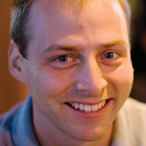

**Kory Draughn - Chief Technologist**

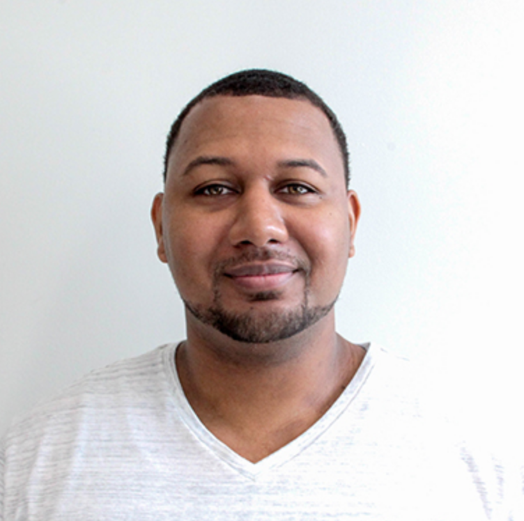

## What is iRODS

- **Distributed**
  - Runs on a laptop, a cluster, on premises or geographically distributed
- **Open Source**
  - BSD-3 Licensed, install it today and try before you buy
- **Data Centric & Metadata Driven**
  - Insulate both your user and your data from your infrastructure

## iRODS as the Integration Layer

## iRODS Core Competencies

## Data Virtualization

[figure not shown]

Combine various distributed storage technologies into a Unified Namespace

- Existing file systems
- Cloud storage
- On premises object storage
- Archival storage systems

*iRODS provides a logical view into the complex physical representation of your data, distributed geographically, and at scale*

## Projection of the Physical into the Logical

## Data Discovery

[figure not shown]

Attach metadata to any first class entity within the iRODS Zone

- Data Objects
- Collections
- Users
- Storage Resources
- The Namespace

*iRODS supports automated and user-provided metadata which makes your data and infrastructure more discoverable, operational, and valuable*

## Metadata Everywhere

## Workflow Automation

[figure not shown]

Policy Enforcement Points (PEPs) are triggered by every operation within the framework

- Authentication
- Storage
- Database Interaction
- Network Activity
- Extensible RPC API

*The iRODS rule engine framework provides the ability to capture real world policy as computer actionable rules which may allow, deny, or add context to operations within the system.*

## Dynamic Policy Enforcement

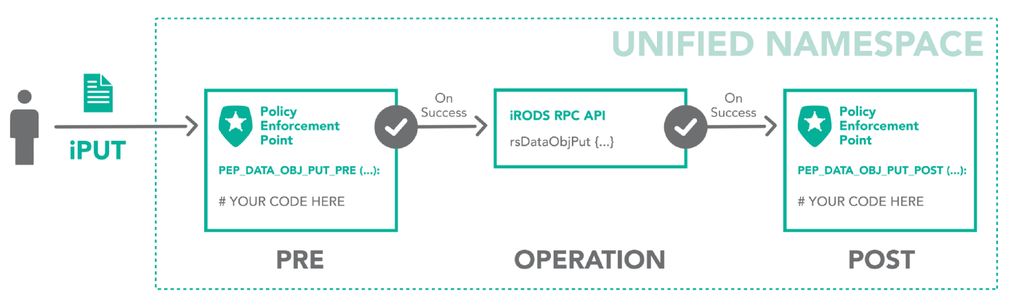

The iRODS rule may:

- restrict access
- log for audit and reporting
- provide additional context
- send a notification

## Secure Collaboration

[figure not shown]

iRODS allows for collaboration across administrative boundaries after deployment

- No need for common infrastructure
- No need for shared funding
- Affords temporary collaborations

*iRODS provides the ability to federate namespaces across organizations without pre-coordinated funding or effort.*